# DSCI353-353m-453: Class 01a Intro Class

Profs: R. H. French, L. S. Bruckman, P. Leu, K. Davis, M. Li, S. Cirlos

TAs: W. Oltjen, K. Hernandez, M. Li, D. Colvin

19 January, 2023

License: [CC-BY-SA 4.0](https://creativecommons.org/licenses/by-sa/4.0/)

#### Class Readings, Assignments, Textbooks Syllabus Topics

##### Textbooks

-Text Books for DSCI353/353M/453

- [R4DS: Wickham: R for Data Science](https://r4ds.had.co.nz/)
- [ISLR: Intro to Statistical Learning with R, 2nd Ed.](https://www.statlearning.com/)
- DLwR: Deep Learning with R, Chollet, Allaire,
- [DLGB: Deep Learning, Goodfellow, Bengio, Courville](https://www.deeplearningbook.org/)
- Magazine Articles about Deep Learning
  - DL1 to DL12 are “Deep Learning” articles in 3-readings/2-articles/
- Books from DSCI351/351M/451
  - [Peng: R Programming for Data Science](https://leanpub.com/rprogramming)
  - [Peng: Exploratory Data Analysis with R](https://leanpub.com/exdata)
  - [Open Intro Stats, v4](https://openintro.org/os)
  - [R4DS: Wickham: R for Data Science](https://r4ds.had.co.nz/)

##### Tidyverse Cheatsheets, Functions and Reading Your Code

- Look at the Tidyverse Cheatsheet
  - **Tidyverse For Beginners Cheatsheet**
    - In the Git/20s-dsci353-353m-453-prof/3-readings/3-CheatSheets/ folder
  - **Data Wrangling with dplyr and tidyr Cheatsheet**

  Tidyverse Functions & Conventions
  - The pipe operator `%>%`
  - Use `dplyr::filter()` to subset data row-wise.
  - Use `dplyr::arrange()` to sort the observations in a data frame
  - Use `dplyr::mutate()` to update or create new columns of a data frame
  - Use `dplyr::summarize()` to turn many observations into a single data point
  - Use `dplyr::arrange()` to change the ordering of the rows of a data frame
  - Use `dplyr::select()` to choose variables from a tibble,
    - keeps only variables you mention
  - Use `dplyr::rename()` keeps all the variables and renames variables
    - rename(iris, petal_length = Petal.Length)
  - These can be combined using `dplyr::group_by()`
    - which lets you perform operations “by group”.
  - The `%in%` matches conditions provided by a vector using the c() function
  - The **forcats** package has tidyverse functions
    - for factors (categorical variables)
  - The **readr** package has tidyverse functions
    - to read_…, melt_… col_…, parse_… data and objects

Reading Your Code: Whenever you see

- The assignment operator `<-`, think **“gets”**
- The pipe operator, `%>%`, think **“then”**

##### Syllabus

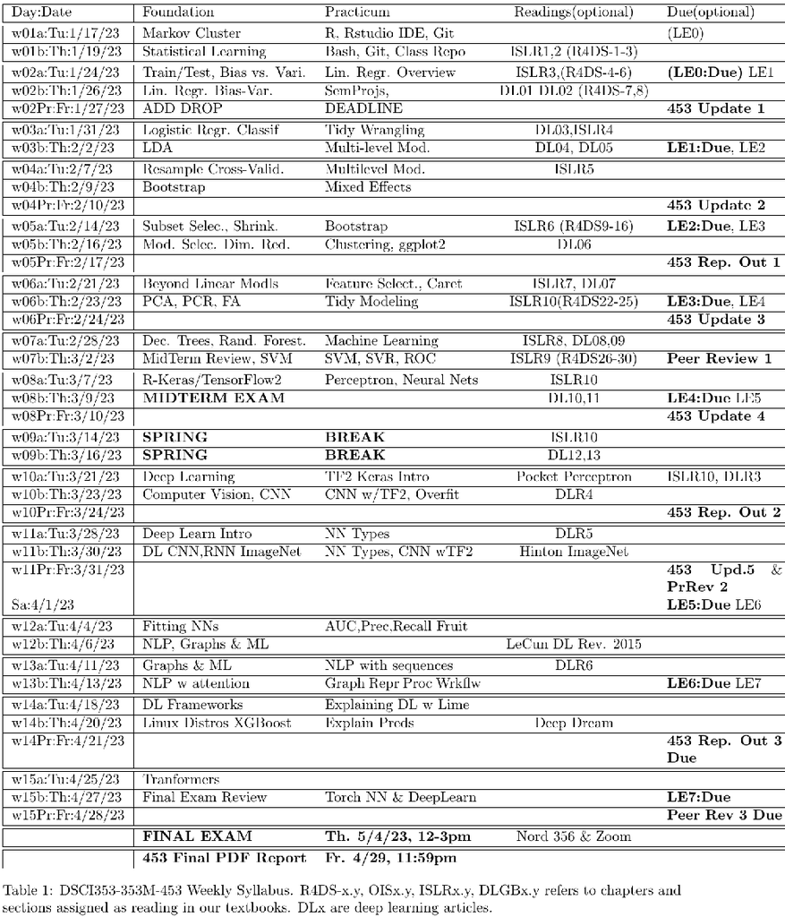

#### The DSCI courses and class sections

##### In these Applied Data Science (DSCI) classes

- We focus on teaching all necessary data science skills
  - Including coding in R
  - Use of Rmarkdown for data analysis reports and presentations
  - Git for code versioning and collaboration
  - Linear and non-linear regression and classification
  - Beyond linear modeling, including Support Vector Machines, Random Forest
  - Machine Learning, including Neural Networks, non-parametric regression
  - Deep Learning, including Keras/TensorFlow running on GPUs

##### The course sections

- DSCI35x (x = 1,3,2)
  - Is undergraduate class for “general” applied data science
- DSCI35xM (x=1,2,3) focuses on materials science systems
- DSCI45x (x=1,2,3)
  - Is a graduate level class
  - With the same class material and DSCI35x
  - Additionally the students do a 40 point Semester Data Analysis Project

And we have University of Pittsburgh (Pitt) students

- Taken E1453 and E2453
- With Prof. Paul Leu and TA Mingxuan Li

##### The specific courses

- DSCI351, 351M, 451
  - Is an introduction to Exploratory Data Science
- DSCI353, 353M, 453
  - Focuses on Modeling, Prediction and Machine Learning
- DSCI 352, 352M, 452
  - Is a Semester long Data Science Project Class
  - Providing a data analysis for inclusion
  - In your Data Science Portfolio
- DSCI 354, 354M, 454
  - Is on Data Visualization and Analytics
  - Alternative Level 5 course for the ADS UG Minor

##### DSCI45x Graduate level courses

- For graduate students,
  - DSCI451 is not listed as a suggested prerequisite
- Therefore some DSCI453 grad. students
  - Do not have familiarity with Open Data Science, R, Git etc.
- For these “New to R” students
  - The initial weeks in class have optional content
  - To get people familiar with Open Data Science

##### Semester Data Science Projects

- Are done in DSCI352, 352M by students who have completed both DSCI351,3
- And by graduate students in DSCI 451, 453 and 452

For DSCI45x students, their Semester Project is developed in the DSCI352 course

- With Prof. Laura Bruckman
- During team meetings during Friday Community Hour
  - 12:45 to 1:45 in Olin 303
- And during class office hours
  - Monday/Wednesday 4pm to 5pm in White 540
- There are weekly SemProj updates due each week on progress
- And 3 SemProj Presentations in DSCI35x class

##### Care should be taken when choosing SemProj datasets.

- Report Out 1 focuses on
  - Explaining the ‘why’ of your research project
  - Describing your dataset
  - Presenting an analysis plan
  - Cleaning your data
- Report Out 2 focuses on:
  - EDA of your data
  - Visualizing your data
  - Further cleaning of your data
  - Reevaluation of your data analysis plan (Do you need more data?)
- Report Out 3:
  - More data visualization
  - Initial modeling
  - Conclusions about your data
  - Were you able to answer your why question?
  - What else would you need to do to get to understanding your data better?

#### Syllabus

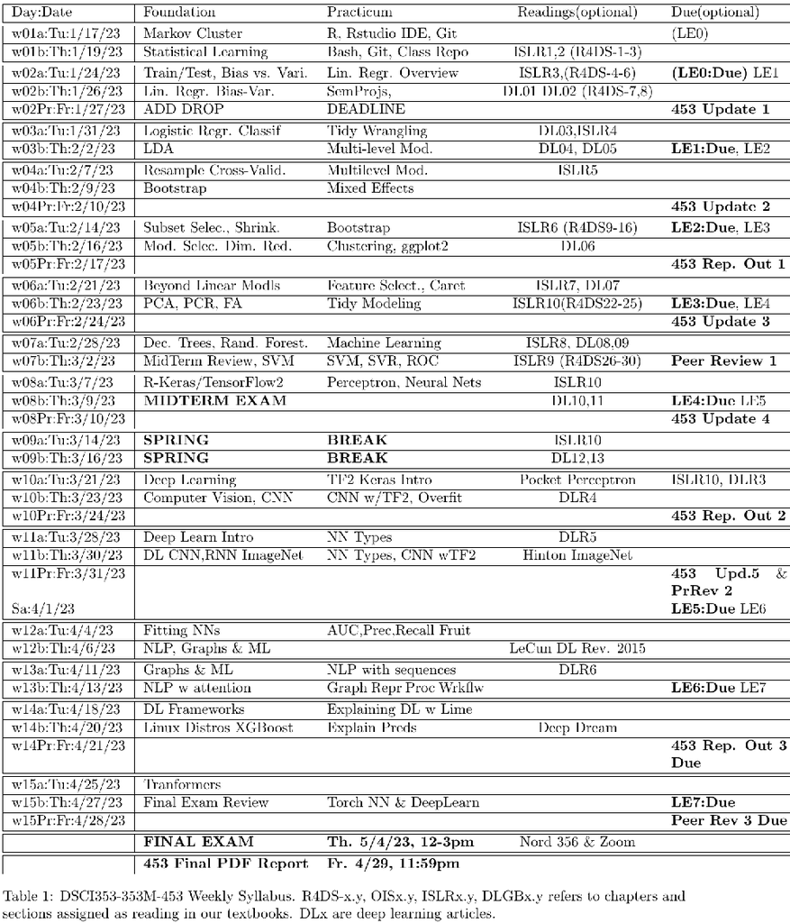

Modeling, Prediction and Machine Learning Syllabus

#### Open Data Science (ODS) & HPC Compute Engines

- You can do data analysis on your notebook computer
  - You can setup your own notebook
    - For data science using R or Python
    - Full instructions are in the class syllabus, section 11
    - For Linux, Mac’s or Windows Operating Systems
    - But Many times you’ll need more compute power than your notebook
    - Such as GPUs (Graphics Processing Units) to accelerate computations

But its useful to learn about a variety of Compute Resources

- In Class we’ll use
  - Markov Data Science Cluster
    - A high performance computing cluster
  - or Open Data Science Desktops

These are all configured the same

- Independent of the Operating System
- They have R with Rstudio IDE (Integrated Development Environment)
- Git for code versioning
- LaTeX for publication quality report generation
- And also Python3 with PyCharm IDE

##### The two cloud computing systems: Markov HPC Cluster & ODS Win10 Desktop

- Markov Data Science HPC Cluster
  - Log in to http://ondemand.case.edu
  - Using your CaseID and password
  - Launch the SDLE Rstudio Server-4.1.1
  - You can also get a KDE Desktop on Markov

##### CWRU HPC provides Markov

- [CWRU’s HPC (High Peformance Computing) Markov Cluster](https://sites.google.com/a/case.edu/hpcc/)
  - This runs RedHat Linux version 7
  - Has 4400 CPU cores
  - Has 100,000 GPU cores
  - Up to a terabyte of Ram
- And has a new Data Science Cluster, named [Markov.case.edu](https://markov.case.edu)
  - With a Hadoop Cluster for distributed computing
  - And dedicated GPUs
- You’ll get accounts on CWRU HPC
- And use http://ondemand.case.edu
  - To login to Markov and get a KDE Desktop session

[figure not shown]

Markov Cluster

##### You also have access to the ODS Win10 Desktops

- These are cloud Windows computers
  - That you log into from a Browser
  - login to http://myapps.case.edu
  - With your CaseID and password
- The ODS VDIs are Windows 10 computers
- The ODS VDIs don’t have GPUs

Not for class, but for your own data science projects.

##### And you can also use [Google’s Kaggle.com](http://www.kaggle.com)

- Here one can run R or Python
- Using [Jupyter Notebooks](https://jupyter.org/) Interface
- Has Free GPUs

- For Jupyter Notebooks
- Running Python3
- Doesn’t support R language yet
- Free GPUs and [TPUs (Tensor Processing Unit)](https://en.wikipedia.org/wiki/Tensor_processing_unit)

#### Operating Systems: Windows, OSX and Linux

- Command Line Environments
  - Linux: Bash on Linux, or Git Bash on Windows
  - Mac OSX: Bash in Terminal
  - Windows: Command.com Terminal
  - In R: R Console, or Console in RStudio

##### Basic/Universal Rules

- No Spaces in Filenames
- Only 1 period in a filename, before file extension
- No other periods
- Only Letters, Underscore (_), and Dashes (-) in Filenames
- In code scripts, use forward slash in all file paths and directories
- You can use CamelBack or snake_case in variable or file names
  - To make code easier to read.
- Code Style is Rstudio or Google R style
- No use of = for Assignments
- Only use <- as the Assignment Operator in R
  - Rstudio Cheat Sheet says <- is “Alt -” in R code

#### Quick Introduction to R/Rstudio/Git

- R is the statistical programming language

Rstudio is the Integrated Development Environment (IDE)

Git is the distributed content versioning system

#### What we need to do this week

- 1. Setup our Markov and Open Data Science (ODS) Computers
  - For Markov Data Science Cluster
    - login to http://ondemand.case.edu
    - Launch the SDLE Rstudio Server-4.1.1
  - For the ODS Desktop
    - Rstudio
    - Drag icons of R, Rstudio, Git Bash, Spyder, Jupyter Notebook, DSCI Slack
      - to desktop
  2. Setup Git
  - make /home/caseID/Git folder on Markov
    - git config your name and email of your git server
  - make H:\Git folder on ODS Desktop
    - git config your name and email of your git server
  3. Setup Bitbucket account
  4. Setup [DSCI Slack Account](http://cwru-dsci.slack.com)
  5. Setup StackExchange account
  6. Git Fork the Class “Prof” Repo
  - In your Bitbucket Account
  8. Git Clone your Fork of the Class Repo

##### So go make accounts, using your case.edu email address

- Most students have already been invited
  - Pitt students have been issued CaseIDs
    - That you will use for logging in to
    - Markov
    - ODS Desktop
    - DSCI Slack
    - CWRU Canvas
- Our DSCI Slack class channel
  - [CWRU Data Science Slack](http://cwru-dsci.slack.com)
  - This is [an invite link to CWRU DSCI Slack](https://join.slack.com/t/cwru-dsci/shared_invite/zt-gy4t8444-WZifMnxeReZRw8q~uJUxpQ)
- For you cloud Git server
  - [Bitbucket.org](http://bitbucket.org)
- A [Stack Exchange account](https://stackexchange.com/)